# Building Shiny Apps

October 20, 2016

## Quick Intro

## About me:

- PhD Applied Mathematics, Université Pierre et Marie Curie, Paris, France.
- 3+ years experience as Adjunct Professor in Mexico.
- 6+ years experience in mathematical modelling (in one way or another).
- Freelance Data Science and Big Data Consultant.
- Building Shiny apps for happy clients since 2015.

## This course

- Minimal coherent stack to help you **get things done**.
- NOT a course in web development.
- No previous knowledge assumed.
- **Topics:**
  - Data manipulation.
  - Shiny.
  - Gathering data.
  - Maps and Graphics.

## Web development

Most web applications consist of three layers that interact with each other.

1. **Front-end**: what the user sees and interacts with (HTML, CSS, Javascript/jQuery).
2. **Middleware**: communicates with the front and back-end
   - Process HTTP requests.
   - Connect to the server.
   - Interact with APIs.
   - Manage cookies, authentication, sessions.
3. **Back-end**: Data storage, process and analysis.

## Why Shiny?

- Get off the ground quickly, using R only.
- Analysts can easily communicate their results.
- Good for applications with more algorithms than users.
- Compatible with other excellent graphics libraries.
- Used in production!

## R and dplyr

## What is R?

- Created by NZ Researchers Ross Ihaka and Robert Gentleman in 1991.
- Derived from the S language, developed in the 1950's in Bell Labs.
- Free (both as in "free beer" and "free person") statistical package.

## What is R good for?

- Extensive package library for math and statistics.
- Decent graphic libraries.
- Quick way to build prototypes, and in many cases, production ready applications.
- Good alternative to LaTeX.
- You can also make slides :)

## What is R not so good for?

- Computations that require intensive data crunching.
- Packages don't play well with each other.
- The documentation can be unreadable, in general little attention to good software development practices, which can become annoying.

## What is dplyr?

- "A fast, consistent tool for working with data frame like objects, both in memory and out of memory".
- Created by Hadley Wickham (Rice University/RStudio).
- Part of a suite of very useful packages for data manipulation in R (we'll cover ggplot2 as well).

## R in a nutshell

## Basic Syntax

- The assignment operator is <-

```r
x <- 1
print(x)
```

```
## [1] 1
```

You can use "=", but "<-" is preferred by the R community (shortcut: Alt + - in RStudio)

## Types

```r
# Vectors and types
x <- c(0.5,0.6) #numeric
x <- c(T,F) #logical
x <- c("a","b","c") #character
x <- c(1+0i,2+4i) #complex
```

```r
# Compressed notation for vectors with consecutive integers:

x <- 9:29
print(x)
```

```
##  [1]  9 10 11 12 13 14 15 16 17 18 19 20 21 22 23 24 25 26 27 28 29
```

## Coercion

```r
# Coercion to types
x <- 0:6
class(x)
```

```
## [1] "integer"
```

```r
as.logical(x)
```

```
## [1] FALSE  TRUE  TRUE  TRUE  TRUE  TRUE  TRUE
```

```r
as.character(x)
```

```
## [1] "0" "1" "2" "3" "4" "5" "6"
```

## Not always possible!

```r
x <- c("a","b","c")
as.numeric(x)
```

```
## [1] NA NA NA
```

## Special values in R

- **NA** is used for existing, but useless values.
- **NaN** is used for undefined values, like 0/0.
- **NULL** means unexistant value.
- There's also **Inf** and **-Inf**.

## Example

```r
v <- c(1, 2, 3, NA, 5)
sum(v)
```

```
## [1] NA
```

```r
v <- c(1, 2, 3, NaN, 5)
sum(v)
```

```
## [1] NaN
```

```r
v <- c(1, 2, 3, NULL, 5)
sum(v)
```

```
## [1] 11
```

## Test for values

```r
is.na(5)
```

```
## [1] FALSE
```

```r
is.na(NaN)
```

```
## [1] TRUE
```

```r
is.nan(NA)
```

```
## [1] FALSE
```

## Factors

```r
x <- factor(c("yes","no", "yes", "no", "no"))
x
```

```
## [1] yes no  yes no  no
## Levels: no yes
```

Factors are special ways of representing data internally, and they are treated specially by modelling functions.

## Data Frames

```r
df <- data.frame( Weather = c("Cold","Mild","Cold","Ok")
               , Cities = c("Prague", "Brno", "Ostrava", "Zlin")
               )
df
```

```
##   Weather  Cities
## 1    Cold  Prague
## 2    Mild    Brno
## 3    Cold Ostrava
## 4      Ok    Zlin
```

## Loading and inspecting

```r
news<-read.csv('./data/OnlineNewsPopularity/OnlineNewsPopularity.csv')

small <- news[2:5]
head(small) # Too many columns
```

```
##   timedelta n_tokens_title n_tokens_content n_unique_tokens
## 1       731             12              219       0.6635945
## 2       731              9              255       0.6047431
## 3       731              9              211       0.5751295
## 4       731              9              531       0.5037879
## 5       731             13             1072       0.4156456
## 6       731             10              370       0.5598886
```

```r
tail(small, n = 3)
```

```
##       timedelta n_tokens_title n_tokens_content n_unique_tokens
## 39642         8             10              442       0.5163551
## 39643         8              6              682       0.5394933
## 39644         8             10              157       0.7019868
```

```r
summary(small)
```

```
##    timedelta     n_tokens_title n_tokens_content n_unique_tokens
##  Min.   :  8.0   Min.   : 2.0   Min.   :   0.0   Min.   :  0.0000
##  1st Qu.:164.0   1st Qu.: 9.0   1st Qu.: 246.0   1st Qu.:  0.4709
##  Median :339.0   Median :10.0   Median : 409.0   Median :  0.5392
##  Mean   :354.5   Mean   :10.4   Mean   : 546.5   Mean   :  0.5482
##  3rd Qu.:542.0   3rd Qu.:12.0   3rd Qu.: 716.0   3rd Qu.:  0.6087
##  Max.   :731.0   Max.   :23.0   Max.   :8474.0   Max.   :701.0000
```

```r
table(news$data_channel_is_lifestyle)
```

```
##
##     0     1
## 37545  2099
```

```r
table(news$data_channel_is_lifestyle, news$data_channel_is_bus)
```

```
##
##         0     1
##   0 31287  6258
##   1  2099     0
```

```r
# Try table(news$data_channel_is_lifestyle,
# news$data_channel_is_entertainment, news$data_channel_is_bus) !
```

## Histograms

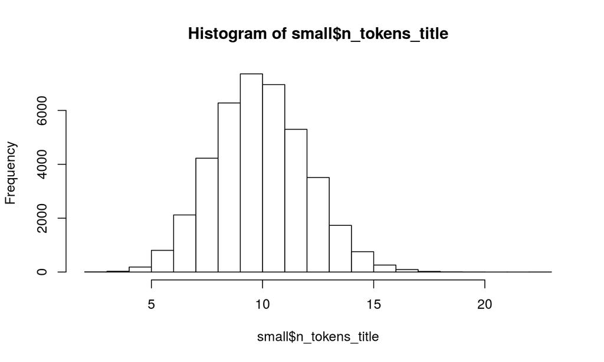

```r
hist(small$n_tokens_title)
```

## Boxplots

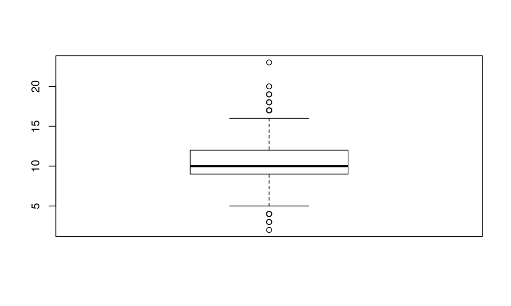

```r
boxplot(small$n_tokens_title)
```

## dplyr

## A grammar for data manipulation

dplyr provides a function for each basic action with data:

- filter() (and slice())
- arrange()
- select() (and rename())
- distinct()
- mutate() (and transmute())
- summarise()
- sample_n() (and sample_frac())

which can do many things together with the "%>%" (read "and then")

## Loading dplyr

```r
library(dplyr)
```

## Example: filter()

```r
# Filter the articles from a specific day
oldest <- filter(small, timedelta == 731 )
head(oldest, n = 2)
```

```
##   timedelta n_tokens_title n_tokens_content n_unique_tokens
## 1       731             12              219       0.6635945
## 2       731              9              255       0.6047431
```

## Example: filter() (cont.)

or, using the operator %>%:

```r
small %>% filter(timedelta==731) %>% head(n=2)
```

```
##   timedelta n_tokens_title n_tokens_content n_unique_tokens
## 1       731             12              219       0.6635945
## 2       731              9              255       0.6047431
```

In pure R (without dplyr), we can do

```r
oldest <- small[small$timedelta==731,]
head(oldest, n = 2 )
```

```
##   timedelta n_tokens_title n_tokens_content n_unique_tokens
## 1       731             12              219       0.6635945
## 2       731              9              255       0.6047431
```

## Example: slice()

slice() filters rows by position, for instance:

```r
slice(small, 16:20)
```

```
##   timedelta n_tokens_title n_tokens_content n_unique_tokens
## 1       731             12              682       0.4595420
## 2       731              8             1118       0.5123967
## 3       731              8              397       0.6246787
## 4       731             11              103       0.6893204
## 5       731              8             1207       0.4105793
```

## Example: arrange()

arrange() orders columns and helps to break ties.

```r
small %>%
  arrange(timedelta, n_tokens_title, n_tokens_content) %>%
  head(n=3)
```

```
##   timedelta n_tokens_title n_tokens_content n_unique_tokens
## 1         8              6              682       0.5394933
## 2         8              8             2509       0.3488781
## 3         8             10              157       0.7019868
```

## Example: arrange() (cont.)

We can use desc() to arrange a column in descending order.

```r
small %>%
  arrange(desc(timedelta), n_tokens_title, n_tokens_content) %>%
  head(n=3)
```

```
##   timedelta n_tokens_title n_tokens_content n_unique_tokens
## 1       731              5              356       0.6182336
## 2       731              6              109       0.6666667
## 3       731              6              174       0.6918605
```

## Example: select()

We can use select to, well, select specific columns:

```r
small %>% select(timedelta,n_tokens_content) %>% head(n=2)
```

```
##   timedelta n_tokens_content
## 1       731              219
## 2       731              255
```

```r
small %>% select(-c(n_tokens_title,n_tokens_content)) %>% head(n=2)
```

```
##   timedelta n_unique_tokens
## 1       731       0.6635945
## 2       731       0.6047431
```

## Example: select() (cont.)

We can use select() also to rename columns

```r
small %>% select(words_in_title = n_tokens_title) %>% head(n=3)
```

```
##   words_in_title
## 1             12
## 2              9
## 3              9
```

## Example: rename()

This is useful to rename a column without dropping the other variables

```r
small %>% rename(words_in_title = n_tokens_title) %>% head(n=3)
```

```
##   timedelta words_in_title n_tokens_content n_unique_tokens
## 1       731             12              219       0.6635945
## 2       731              9              255       0.6047431
## 3       731              9              211       0.5751295
```

## Example: distinct()

This function allows us to find unique values in a table

```r
small %>% distinct(timedelta) %>% head(n=3)
```

```
##   timedelta
## 1       731
## 2       730
## 3       729
```

```r
small %>% distinct(timedelta,n_tokens_title) %>% nrow
```

```
## [1] 6792
```

## Example: mutate()

Sometimes we need to add new columns that are function of existing columns, for instance:

```r
small %>%
  mutate(title_to_content = n_tokens_title/n_tokens_content
         ,total_unique = n_tokens_content * n_unique_tokens ) %>%
  head(n=3)
```

```
##   timedelta n_tokens_title n_tokens_content n_unique_tokens
## 1       731             12              219       0.6635945
## 2       731              9              255       0.6047431
## 3       731              9              211       0.5751295
##   title_to_content total_unique
## 1       0.05479452     145.3272
## 2       0.03529412     154.2095
## 3       0.04265403     121.3523
```

## Example: mutate() (cont.)

We can recycle newly created variables!

```r
small %>%
  mutate(title_to_content = n_tokens_title/n_tokens_content
         ,percentage = round(100*title_to_content,2) ) %>%
  head(n=3)
```

```
##   timedelta n_tokens_title n_tokens_content n_unique_tokens
## 1       731             12              219       0.6635945
## 2       731              9              255       0.6047431
## 3       731              9              211       0.5751295
##   title_to_content percentage
## 1       0.05479452       5.48
## 2       0.03529412       3.53
## 3       0.04265403       4.27
```

## Example: transmute()

Like mutate(), but keeps only the newly created variables

```r
small %>%
  transmute(title_to_content = n_tokens_title/n_tokens_content
         ,total_unique = n_tokens_content * n_unique_tokens ) %>%
  head(n=3)
```

```
##   title_to_content total_unique
## 1       0.05479452     145.3272
## 2       0.03529412     154.2095
## 3       0.04265403     121.3523
```

## Sampling: sample_n() and sample_frac()

These two functions allow us to sample randomly a fixed number of rows or a fraction. Use replace = TRUE for a sample with replacement, and you can add weights for the sampling if needed. More info in ?sample_n

## Grouping functions

All the functions above become really useful when we can apply them to groups.

```r
gps <- news %>%
  sample_frac(.1)%>%
  group_by(data_channel_is_lifestyle
          ,data_channel_is_world)%>%
  summarise(count=n()
            ,avg_imgs = mean(num_imgs, na.rm = TRUE)
            , avg_videos =mean(num_videos, na.rm = TRUE))
```

## Plotting the final results

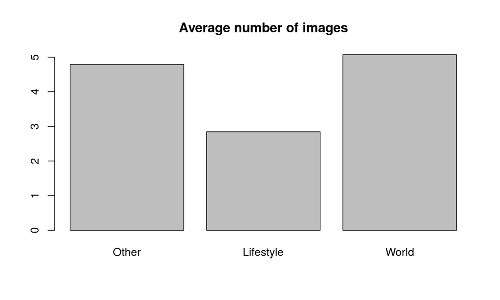

```r
barplot(gps$avg_imgs
        , names.arg = c("Other", "Lifestyle", "World")
        , main = "Average number of images")
```

## Another useful plot

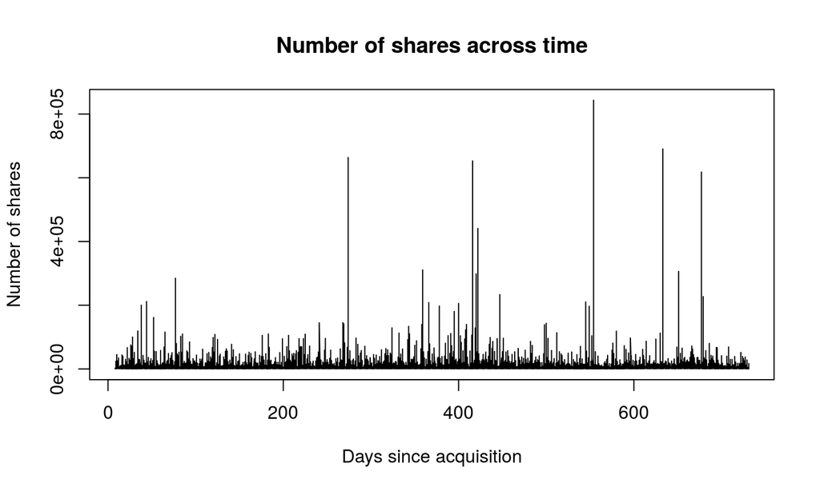

```r
plot(news$timedelta,news$shares
     , type='l', main = "Number of shares across time"
     , xlab = "Days since acquisition", ylab = "Number of shares")
```

## Hands-on

Try it yourselves! Let's test some hypothesis:

- What are the 5 most shared articles?
- Which channel (among the six described) has the largest average number of shares? does it change across time?
- Which day has the most shares, on average?

## What are the 5 most shared articles?

```r
news %>% arrange(desc(shares)) %>% select(url,shares) %>% head(n=5)
```

```
##                                                                   url
## 1                     http://mashable.com/2013/07/03/low-cost-iphone/
## 2             http://mashable.com/2013/04/15/dove-ad-beauty-sketches/
## 3 http://mashable.com/2014/04/09/first-100-gilt-soundcloud-stitchfix/
## 4          http://mashable.com/2013/11/18/kanye-west-harvard-lecture/
## 5                   http://mashable.com/2013/03/02/wealth-inequality/
##   shares
## 1 843300
## 2 690400
## 3 663600
## 4 652900
## 5 617900
```

## Which channel has the largest number of shares?

```r
ex2a <- news %>%
  group_by(data_channel_is_lifestyle
  , data_channel_is_entertainment
  , data_channel_is_bus
  , data_channel_is_socmed
  , data_channel_is_tech
  , data_channel_is_world)%>%
  summarise(avg_shares = mean(shares))
```

## … and the plot:

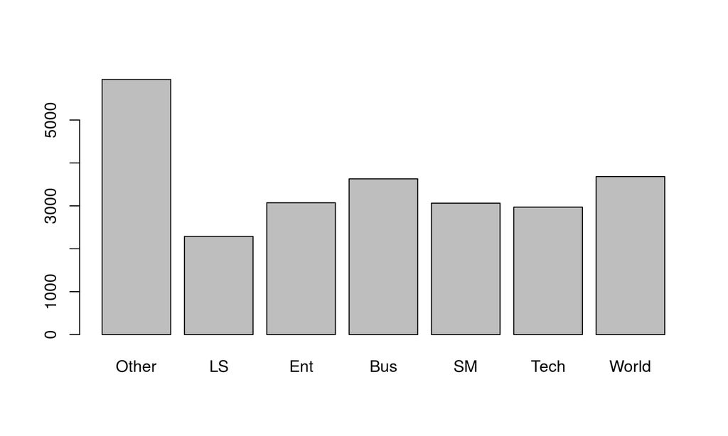

```r
barplot(ex2a$avg_shares,
        names.arg =c("Other","LS","Ent","Bus","SM","Tech","World"))
```

## Does it change with time?

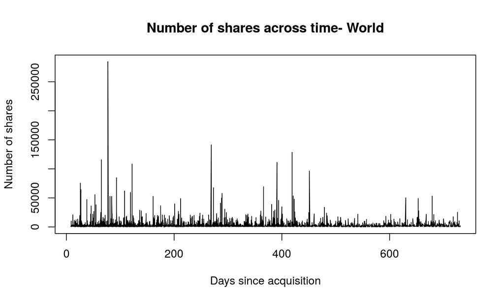

```r
ex2b <- news %>% filter(data_channel_is_world ==1)

plot(ex2b$timedelta,ex2b$shares
     , type='l', main = "Number of shares across time- World"
     , xlab = "Days since acquisition", ylab = "Number of shares")
```

## Which day has the most shares, on average?

```r
ex3 <- news %>%
  group_by(weekday_is_monday
  , weekday_is_tuesday
  , weekday_is_wednesday
  , weekday_is_thursday
  , weekday_is_friday
  , weekday_is_saturday
  , weekday_is_sunday)%>%
  summarise(avg_shares = mean(shares))
```

## and the plot:

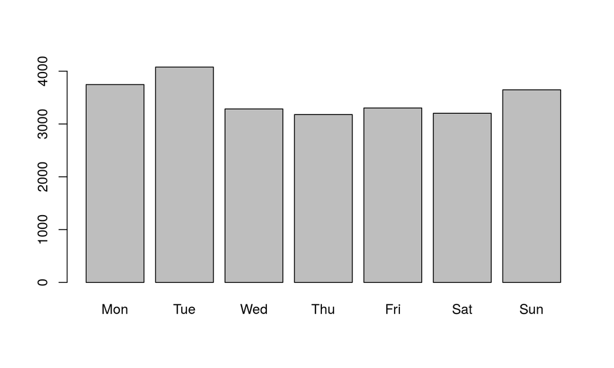

```r
barplot(ex3$avg_shares,
        names.arg =c("Mon", "Tue",'Wed', "Thu", "Fri", "Sat", "Sun"))
```